# Instrument Detection App

Author

Jorge Bris Moreno, Brian Kwon

**Repo:** https://github.com/jbrismor/Instrument_Detection_App

## Description

The following repo aims to create an app for instrument identification. The app can be ran by executing the following command `streamlit run app.py` in your terminal. It takes images and audios, and outputs the predicted instrument that it is with the probability score.

The image classification 7 class can predict the following instruments from a picture:

- Bassoon
- Erhu
- Flute
- French horn
- Guitar
- Saxophone
- Violin

The image classification 12 class can predict the following instruments from a picture:

- Bassoon
- Cello
- Clarinet
- Erhu
- Flute
- French horn
- Guitar
- Harp
- Recorder
- Saxophone
- Trumpet
- Violin

The Audio classification can predict the following instruments from a recorded audio or file upload:

- Banjo
- Bass clarinet
- Bassoon
- Cello
- Clarinet
- Contrabassoon
- Cor anglais
- Double bass
- Flute
- French horn
- Guitar
- Mandolin
- Oboe
- Percussion
- Saxophone
- Trombone
- Trumpet
- Tuba
- Viola
- Violin

The Jupyter notebooks where the models’ training and testing is showcased can be found in the folder `notebooks`. Please refer to it for more information.

## Models:

The audio classification model uses a YAMNet model imported from `tensorflow_hub` that has been frozen and utilized to extract features, which are then fed into a two-layer classification network. Similarly, the image models use frozen RESNET architectures (RESNET18 for the 7-class model and RESNET50 for the 12-class model), with the final layers fine-tuned for the task.

## App example

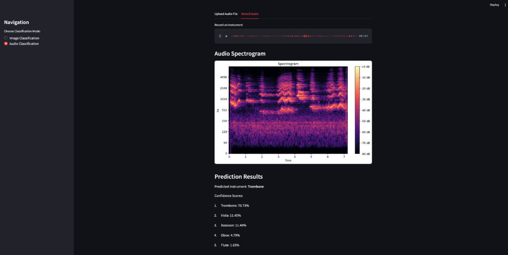

## Reference

[1] Philharmmonia Audio Samples  
https://philharmonia.co.uk/resources/sound-samples/

[2] People Playing Musical Instrument (PPMI)  
https://ai.stanford.edu/~bangpeng/ppmi.html